# Part I - (Ford Gobike Dataset Exploration)

## Introduction

> This data set includes information about individual rides made in a bike-sharing system covering the greater San Francisco Bay area.

## Preliminary Wrangling

```python
# import all packages and set plots to be embedded inline
import pandas as pd
import numpy as np
import matplotlib.pyplot as plt
import seaborn as sb
import math

%matplotlib inline
```

```python
df = pd.read_csv('201902-fordgobike-tripdata.csv')
```

```python
df.shape
```

```
(183412, 16)
```

```python
df.head()
```

|  | duration_sec | start_time | end_time | start_station_id | start_station_name | start_station_latitude | start_station_longitude | end_station_id | end_station_name | end_station_latitude | end_station_longitude | bike_id | user_type | member_birth_year | member_gender | bike_share_for_all_trip |
| --- | --- | --- | --- | --- | --- | --- | --- | --- | --- | --- | --- | --- | --- | --- | --- | --- |
| 0 | 52185 | 2019-02-28 17:32:10.1450 | 2019-03-01 08:01:55.9750 | 21.0 | Montgomery St BART Station (Market St at 2nd St) | 37.789625 | -122.400811 | 13.0 | Commercial St at Montgomery St | 37.794231 | -122.402923 | 4902 | Customer | 1984.0 | Male | No |
| 1 | 42521 | 2019-02-28 18:53:21.7890 | 2019-03-01 06:42:03.0560 | 23.0 | The Embarcadero at Steuart St | 37.791464 | -122.391034 | 81.0 | Berry St at 4th St | 37.775880 | -122.393170 | 2535 | Customer | NaN | NaN | No |
| 2 | 61854 | 2019-02-28 12:13:13.2180 | 2019-03-01 05:24:08.1460 | 86.0 | Market St at Dolores St | 37.769305 | -122.426826 | 3.0 | Powell St BART Station (Market St at 4th St) | 37.786375 | -122.404904 | 5905 | Customer | 1972.0 | Male | No |
| 3 | 36490 | 2019-02-28 17:54:26.0100 | 2019-03-01 04:02:36.8420 | 375.0 | Grove St at Masonic Ave | 37.774836 | -122.446546 | 70.0 | Central Ave at Fell St | 37.773311 | -122.444293 | 6638 | Subscriber | 1989.0 | Other | No |
| 4 | 1585 | 2019-02-28 23:54:18.5490 | 2019-03-01 00:20:44.0740 | 7.0 | Frank H Ogawa Plaza | 37.804562 | -122.271738 | 222.0 | 10th Ave at E 15th St | 37.792714 | -122.248780 | 4898 | Subscriber | 1974.0 | Male | Yes |

```python
df.describe()
```

|  | duration_sec | start_station_id | start_station_latitude | start_station_longitude | end_station_id | end_station_latitude | end_station_longitude | bike_id | member_birth_year |
| --- | --- | --- | --- | --- | --- | --- | --- | --- | --- |
| count | 183412.000000 | 183215.000000 | 183412.000000 | 183412.000000 | 183215.000000 | 183412.000000 | 183412.000000 | 183412.000000 | 175147.000000 |
| mean | 726.078435 | 138.590427 | 37.771223 | -122.352664 | 136.249123 | 37.771427 | -122.352250 | 4472.906375 | 1984.806437 |
| std | 1794.389780 | 111.778864 | 0.099581 | 0.117097 | 111.515131 | 0.099490 | 0.116673 | 1664.383394 | 10.116689 |
| min | 61.000000 | 3.000000 | 37.317298 | -122.453704 | 3.000000 | 37.317298 | -122.453704 | 11.000000 | 1878.000000 |
| 25% | 325.000000 | 47.000000 | 37.770083 | -122.412408 | 44.000000 | 37.770407 | -122.411726 | 3777.000000 | 1980.000000 |
| 50% | 514.000000 | 104.000000 | 37.780760 | -122.398285 | 100.000000 | 37.781010 | -122.398279 | 4958.000000 | 1987.000000 |
| 75% | 796.000000 | 239.000000 | 37.797280 | -122.286533 | 235.000000 | 37.797320 | -122.288045 | 5502.000000 | 1992.000000 |
| max | 85444.000000 | 398.000000 | 37.880222 | -121.874119 | 398.000000 | 37.880222 | -121.874119 | 6645.000000 | 2001.000000 |

```python
df.info()
```

```
<class 'pandas.core.frame.DataFrame'>
RangeIndex: 183412 entries, 0 to 183411
Data columns (total 16 columns):
 #   Column                   Non-Null Count   Dtype
---  ------                   --------------   -----
 0   duration_sec             183412 non-null  int64
 1   start_time               183412 non-null  object
 2   end_time                 183412 non-null  object
 3   start_station_id         183215 non-null  float64
 4   start_station_name       183215 non-null  object
 5   start_station_latitude   183412 non-null  float64
 6   start_station_longitude  183412 non-null  float64
 7   end_station_id           183215 non-null  float64
 8   end_station_name         183215 non-null  object
 9   end_station_latitude     183412 non-null  float64
 10  end_station_longitude    183412 non-null  float64
 11  bike_id                  183412 non-null  int64
 12  user_type                183412 non-null  object
 13  member_birth_year        175147 non-null  float64
 14  member_gender            175147 non-null  object
 15  bike_share_for_all_trip  183412 non-null  object
dtypes: float64(7), int64(2), object(7)
memory usage: 22.4+ MB
```

**Observation:**

Although this dataset looks somewhat clean, some of the columns have missing values and a number of the datatypes need to be changed in order to suit the purpose of this project.

```python
#find the sum of null rows in the dataset
df.isnull().sum()
```

```
duration_sec                  0
start_time                    0
end_time                      0
start_station_id            197
start_station_name          197
start_station_latitude        0
start_station_longitude       0
end_station_id              197
end_station_name            197
end_station_latitude          0
end_station_longitude         0
bike_id                       0
user_type                     0
member_birth_year          8265
member_gender              8265
bike_share_for_all_trip       0
dtype: int64
```

```python
#check for duplicate rows
df.duplicated().sum()
```

```
0
```

```python
df.member_gender.value_counts()
```

```
Male      130651
Female     40844
Other       3652
Name: member_gender, dtype: int64
```

```python
df.user_type.value_counts()
```

```
Subscriber    163544
Customer       19868
Name: user_type, dtype: int64
```

```python
df.bike_share_for_all_trip.value_counts()
```

```
No     166053
Yes     17359
Name: bike_share_for_all_trip, dtype: int64
```

### What is the structure of your dataset?

The dataset consists of 183412 trip records and 16 attributes which include both numeric and categorical features, the trip records represent the rows while the attributes represent the columns.

### What is/are the main feature(s) of interest in your dataset?

The main features of interest to me are:

1. The distance covered by users.
2. The average duration spent by each user on a ride.
3. How gender affects distance and duration covered.

### What features in the dataset do you think will help support your investigation into your feature(s) of interest?

> The user_type as well as the duration_sec features will help in finding the relationship between users and average completion time.

> The Start_date feature will help in understanding the most frequent time of the day when trips are started.

> The member_birth_year will give more insight into the age of the riders and thus the relationship between age and mean time to complete a ride.

> The start station name will help in finding the most frequent start stations.

> Bike_id when compared with distance will help share insight on if there is a bike that is much more preferred than others.

## Data Cleaning

```python
# make a copy of the dataframe for data cleaning and manipulation
df_clean = df.copy()
```

```python
#change the datatypes for both start and end times
df_clean['start_time'] = pd.to_datetime(df_clean['start_time'])
df_clean['end_time'] = pd.to_datetime(df_clean['end_time'])
```

```python
#change datatyoes of all the id columns to string
df_clean['start_station_id'] = df_clean['start_station_id'].astype('str')
df_clean['end_station_id'] = df_clean['end_station_id'].astype('str')
df_clean['bike_id'] = df_clean['bike_id'].astype('str')
```

```python
#change the user_type, member_gender and bike_share_for_all_trip datatype to category
df_clean['user_type'] = df_clean['user_type'].astype('category')
df_clean['member_gender'] = df_clean['member_gender'].astype('category')
df_clean['bike_share_for_all_trip'] = df_clean['bike_share_for_all_trip'].astype('category')
```

```python
#assign variable name to null values in the start_station_name column
null = df_clean[df_clean.start_station_name.isnull()]
```

```python
#drop null values in the start_station_name column
df_clean.drop(null.index, axis = 0, inplace = True)
```

```python
#assign variable name to null values in the member_gender column
null_gender = df_clean[df_clean.member_gender.isnull()]
```

```python
#drop null values in the member_gender column
df_clean.drop(null_gender.index, axis = 0, inplace = True)
```

```python
print(df_clean['user_type'].unique())
print(df_clean['member_gender'].unique())
print(df_clean['bike_share_for_all_trip'].unique())
```

```
['Customer', 'Subscriber']
Categories (2, object): ['Customer', 'Subscriber']
['Male', 'Other', 'Female']
Categories (3, object): ['Female', 'Male', 'Other']
['No', 'Yes']
Categories (2, object): ['No', 'Yes']
```

```python
#check to see that all changes have been effected
df_clean.dtypes
```

```
duration_sec                        int64
start_time                 datetime64[ns]
end_time                   datetime64[ns]
start_station_id                   object
start_station_name                 object
start_station_latitude            float64
start_station_longitude           float64
end_station_id                     object
end_station_name                   object
end_station_latitude              float64
end_station_longitude             float64
bike_id                            object
user_type                        category
member_birth_year                 float64
member_gender                    category
bike_share_for_all_trip          category
dtype: object
```

```python
#check how many years worth of data is available in the dataset
df_clean['start_time'].dt.year.unique()
```

```
array([2019], dtype=int64)
```

**Observation:**

The dataset consists of trips which started in February of 2019

```python
#create a column containing the age of the participants at the time of the trips.
df_clean['age'] = 2019 - df_clean['member_birth_year']
```

```python
#change datatype for the new column
df_clean['age'] = df_clean['age'].astype(int)
```

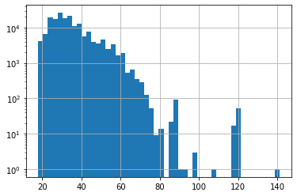

```python
#check for outliers in age
df_clean.age.hist(bins=50 , log = True);
```

```python
#remove outliers from the dataset
df_clean = df_clean.query('age <= 80')
```

```python
#add new columns for trip start hour, day of week, month and year
df_clean['start_hour'] = df_clean.start_time.dt.strftime('%H')
df_clean['start_day'] = df_clean.start_time.dt.strftime('%A')
df_clean['start_month'] = df_clean.start_time.dt.strftime('%B')
df_clean['year'] = df_clean.start_time.dt.strftime('%Y')
```

```python
df_clean['start_hour'] = df_clean['start_hour'].astype(int)
```

```python
start_hour = df_clean['start_hour']
time_bins = [0,6,12,16,20,24]
bin_names = ['Twilight' , 'Morning' , 'Afternoon' , 'Evening', 'Night']
df_clean['time_of_day'] = pd.cut(start_hour , time_bins , right = False , labels = bin_names)
```

```python
df_clean.sample(5)
```

|  | duration_sec | start_time | end_time | start_station_id | start_station_name | start_station_latitude | start_station_longitude | end_station_id | end_station_name | end_station_latitude | ... | user_type | member_birth_year | member_gender | bike_share_for_all_trip | age | start_hour | start_day | start_month | year | time_of_day |
| --- | --- | --- | --- | --- | --- | --- | --- | --- | --- | --- | --- | --- | --- | --- | --- | --- | --- | --- | --- | --- | --- |
| 140195 | 1260 | 2019-02-07 19:12:46.765 | 2019-02-07 19:33:47.134 | 284.0 | Yerba Buena Center for the Arts (Howard St at ... | 37.784872 | -122.400876 | 39.0 | Scott St at Golden Gate Ave | 37.778999 | ... | Subscriber | 1968.0 | Other | No | 51 | 19 | Thursday | February | 2019 | Evening |
| 46267 | 802 | 2019-02-22 09:54:29.384 | 2019-02-22 10:07:51.597 | 74.0 | Laguna St at Hayes St | 37.776435 | -122.426244 | 22.0 | Howard St at Beale St | 37.789756 | ... | Subscriber | 1987.0 | Male | No | 32 | 9 | Friday | February | 2019 | Morning |
| 56816 | 1160 | 2019-02-21 08:34:35.383 | 2019-02-21 08:53:55.885 | 39.0 | Scott St at Golden Gate Ave | 37.778999 | -122.436861 | 21.0 | Montgomery St BART Station (Market St at 2nd St) | 37.789625 | ... | Subscriber | 1978.0 | Female | No | 41 | 8 | Thursday | February | 2019 | Morning |
| 32399 | 374 | 2019-02-24 14:33:14.497 | 2019-02-24 14:39:29.191 | 41.0 | Golden Gate Ave at Polk St | 37.781270 | -122.418740 | 56.0 | Koshland Park | 37.773414 | ... | Subscriber | 1987.0 | Male | No | 32 | 14 | Sunday | February | 2019 | Afternoon |
| 153153 | 221 | 2019-02-06 13:30:24.328 | 2019-02-06 13:34:05.824 | 182.0 | 19th Street BART Station | 37.809013 | -122.268247 | 179.0 | Telegraph Ave at 27th St | 37.816073 | ... | Subscriber | 1993.0 | Female | No | 26 | 13 | Wednesday | February | 2019 | Afternoon |

5 rows × 22 columns

```python
#check for successful execution
print(df_clean['time_of_day'].unique())
```

```
['Evening', 'Afternoon', 'Night', 'Morning', 'Twilight']
Categories (5, object): ['Twilight' < 'Morning' < 'Afternoon' < 'Evening' < 'Night']
```

```python
#derive duration in minutes and add a column to contain values
df_clean['duration_min'] = df_clean['duration_sec']/60
```

```python
# function that calculates the distance between two geographical coordinates in kms base on this solution at below link
# https://gist.github.com/rochacbruno/2883505
def distance(row):
    lat1 = row['start_station_latitude']
    lon1 = row['start_station_longitude']
    lat2 = row['end_station_latitude']
    lon2 = row['end_station_longitude']
    radius = 6371 # km radius of earth
    dlat = math.radians(lat2-lat1)
    dlon = math.radians(lon2-lon1)
    a = math.sin(dlat/2) * math.sin(dlat/2) + math.cos(math.radians(lat1)) \
        * math.cos(math.radians(lat2)) * math.sin(dlon/2) * math.sin(dlon/2)
    c = 2 * math.atan2(math.sqrt(a), math.sqrt(1-a))
    d = radius * c
    return d
```

```python
df_clean['distance'] = df_clean.apply(lambda row: distance(row), axis=1)
```

```python
df_clean.distance.head()
```

```
0    0.544709
2    2.704545
3    0.260739
4    2.409301
5    3.332203
Name: distance, dtype: float64
```

```python
#drop columns that will not be used in the analysis
df_clean.drop(['start_time',
               'duration_sec',
               'end_time',
               'start_station_latitude',
               'start_station_longitude',
               'end_station_latitude',
               'end_station_longitude',
               'start_hour',
               'member_birth_year',
               'end_station_id',
               'start_station_id'], axis=1, inplace=True)
```

```python
# check structure of final dataframe
df_clean.info()
```

```
<class 'pandas.core.frame.DataFrame'>
Int64Index: 174760 entries, 0 to 183411
Data columns (total 13 columns):
 #   Column                   Non-Null Count   Dtype
---  ------                   --------------   -----
 0   start_station_name       174760 non-null  object
 1   end_station_name         174760 non-null  object
 2   bike_id                  174760 non-null  object
 3   user_type                174760 non-null  category
 4   member_gender            174760 non-null  category
 5   bike_share_for_all_trip  174760 non-null  category
 6   age                      174760 non-null  int32
 7   start_day                174760 non-null  object
 8   start_month              174760 non-null  object
 9   year                     174760 non-null  object
 10  time_of_day              174760 non-null  category
 11  duration_min             174760 non-null  float64
 12  distance                 174760 non-null  float64
dtypes: category(4), float64(2), int32(1), object(6)
memory usage: 13.3+ MB
```

```python
#save clean data to a new csv file
df_clean.to_csv('ford_gobike_clean.csv', index=False)
```

```python
ford_2019 = pd.read_csv('ford_gobike_clean.csv')
```

```python
ford_2019.dtypes
```

[output not shown]

```python
# Convert the columns from a plain object type into an ordered categorical type

days = ['Monday', 'Tuesday', 'Wednesday', 'Thursday', 'Friday', 'Saturday', 'Sunday']
day_of_week = pd.api.types.CategoricalDtype(ordered = True, categories = days)
ford_2019['start_day'] = ford_2019['start_day'].astype(day_of_week)


day_time = ['Twilight', 'Morning', 'Afternoon', 'Evening', 'Night']
time_of_day = pd.api.types.CategoricalDtype(ordered = True, categories = day_time)
ford_2019['time_of_day'] = ford_2019['time_of_day'].astype(time_of_day)
```

```python
ford_2019.member_gender = ford_2019['member_gender'].astype('category')
ford_2019.user_type = ford_2019['user_type'].astype('category')
ford_2019.bike_share_for_all_trip = ford_2019['bike_share_for_all_trip'].astype('category')
```

## Univariate Exploration

```python
base_color = sb.color_palette()[0]
```

### What is the age distribution across the dataset?

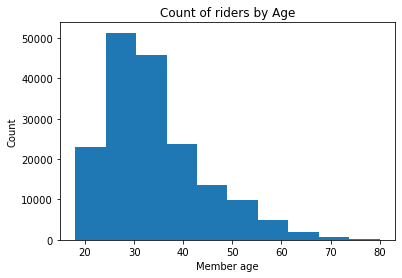

```python
plt.hist(data = ford_2019, x = 'age')

plt.xlabel('Member age')
plt.ylabel('Count')
plt.title('Count of riders by Age');
```

**Observation:** The graph appears to be right skewed with no outliers in view. For more accurate visualization, the bin size will be reduced and the logarithm scale will be applied.

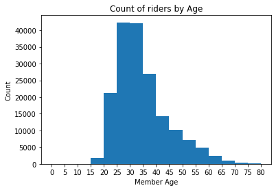

```python
bins = np.arange(0, ford_2019['age'].max()+5, 5)
plt.hist(data=ford_2019, x='age', bins=bins)
plt.xticks(bins, bins)
plt.xlabel('Member Age')
plt.ylabel('Count')
plt.title('Count of riders by Age');
```

```python
# find the min and max age values on th elog scale
np.log10(ford_2019['age'].describe())
```

```
count    5.242442
mean     1.533076
std      0.994658
min      1.255273
25%      1.431364
50%      1.505150
75%      1.591065
max      1.903090
Name: age, dtype: float64
```

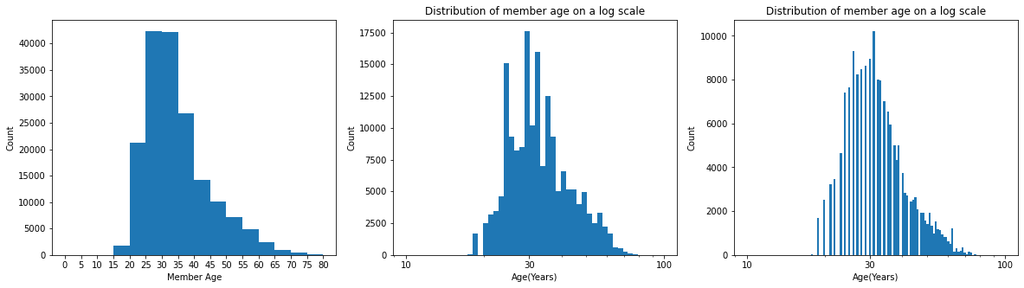

```python
# decrease the bin size and apply logarithm scale
plt.figure(figsize=[20, 5])

plt.subplot(1,3,1)
bins = np.arange(0, ford_2019['age'].max()+5, 5)
plt.hist(data=ford_2019, x='age', bins=bins)
plt.xticks(bins, bins)
plt.xlabel('Member Age')
plt.ylabel('Count')

plt.subplot(1,3,2)
bins = 10 ** np.arange(1 , 2+0.02 , 0.02)
ticks = [10, 30, 100]
labels = ['{}'.format(v) for v in ticks]

plt.hist(data = ford_2019, x = 'age', bins = bins)
plt.title('Distribution of member age on a log scale')
plt.xlabel('Age(Years)')
plt.ylabel('Count')
plt.xscale('log')

plt.xticks(ticks, ticks)

plt.subplot(1,3,3)
bins = 10 ** np.arange(1 , 2+0.008 , 0.008)
ticks = [10, 30, 100]
labels = ['{}'.format(v) for v in ticks]

plt.hist(data = ford_2019, x = 'age', bins = bins)
plt.title('Distribution of member age on a log scale')
plt.xlabel('Age(Years)')
plt.ylabel('Count')
plt.xscale('log')

plt.xticks(ticks, ticks);
```

After applying smaller bin sizes and logarithmic scaling it is clearly evident that the distribution is spread across different ages with most of the riders being less than 50 years old and the youngest being less than 20 years old but older than 15. This indicates that the dataset either did not cover the records for children or that children did not take any rides at the time of this data collection.

```python
ford_2019.age.min()
```

```
18
```

### What user_type records are gathered more?

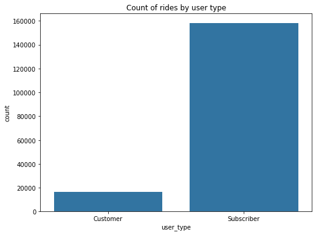

```python
plt.figure(figsize=[8, 6])
sb.countplot(data = ford_2019, x='user_type', color=base_color)

plt.title('Count of rides by user type');
```

There are more subscribers than customers whose records reflect in this dataset.

```python
Subscribers = ford_2019.query('user_type == "Subscriber"').user_type
len(Subscribers)
```

```
158203
```

```python
Customers = ford_2019.query('user_type == "Customer"').user_type
len(Customers)
```

```
16557
```

```python
ratio = len(Subscribers) / len(Customers)
ratio
```

```
9.555052243763967
```

```python
percentage = len(Subscribers) / (len(Subscribers) + len(Customers)) * 100
percentage
```

```
90.5258640421149
```

From the above calculations, there are over 9.5 more subscribers than customers which account for more than 90% of the records in this dataset. This means that most of the people who use the bike company are subscribed to their services.

### What time and day are rides most frequent

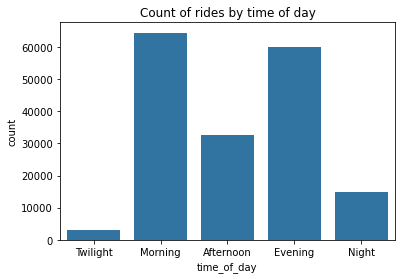

```python
sb.countplot(data=ford_2019, x='time_of_day', color=base_color)

plt.title('Count of rides by time of day');
```

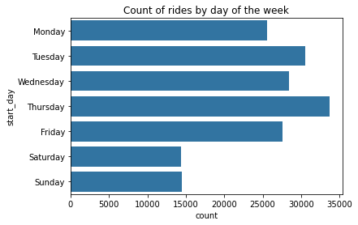

```python
sb.countplot(data=ford_2019, y='start_day', color=base_color)

plt.title('Count of rides by day of the week');
```

The histograms above indicate that most rides were taken on Thursdays, in the mornings and evenings while the least were recorded during the weekend, at night and twilight.

Although Thursdays have the most rides recorded, ride records during the weekdays are significantly higher than during the weekend. We can attribute this to the fact that workdays are mostly during the weekdays and rush hours are usually in the mornings, when people leave for work, and in the evening, when they return.

### How far do riders go and what is the duration of most rides?

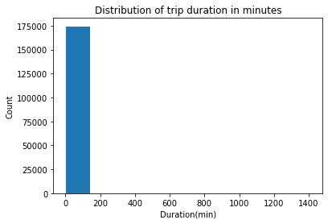

```python
plt.hist(data=ford_2019, x='duration_min');

plt.xlabel('Duration(min)')
plt.ylabel('Count')
plt.title('Distribution of trip duration in minutes');
```

```python
#to get the min and max values of theduration on the log scale
np.log10(ford_2019.duration_min.describe())
```

```
count    5.242442
mean     1.069612
std      1.437495
min      0.007179
25%      0.731051
50%      0.930270
75%      1.118926
max      3.148952
Name: duration_min, dtype: float64
```

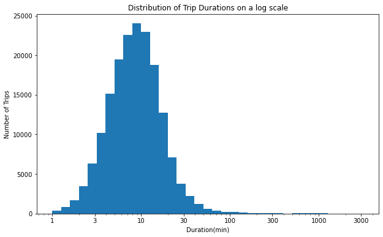

```python
plt.figure(figsize=[10, 6])

bins = 10 ** np.arange(0, 3.5+0.1, 0.1)


ticks = [1, 3, 10, 30, 100, 300, 1000, 3000]
# Convert ticks into string values, to be displayed along the x-axis
labels = ['{}'.format(v) for v in ticks]


plt.hist(data = ford_2019, x = 'duration_min', bins = bins)
plt.title('Distribution of Trip Durations on a log scale')
plt.xlabel('Duration(min)')
plt.ylabel('Number of Trips')
plt.xscale('log')

plt.xticks(ticks, labels);
```

After further investigation, the distribution looks symmetrical with most rides falling within 3 to 30 minutes and the most counts being at at about 10 minutes.

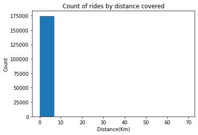

```python
plt.hist(data=ford_2019, x='distance');

plt.xlabel('Distance(Km)')
plt.ylabel('Count')
plt.title('Count of rides by distance covered');
```

**Observation:** Distance covered while using the original scaling method indicates that most rides were less than 10km in distance. To get a better view that captures the spread across different distances, using the log scaling method with smaller bins will be more appropriate.

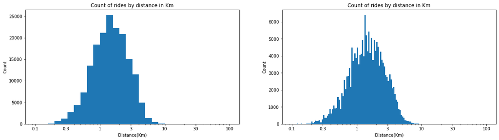

```python
plt.figure(figsize=[20, 5])

plt.subplot(1, 2, 1)
bins = 10 ** np.arange(-1, 2+0.1, 0.1)

ticks = [0.1, 0.3, 1, 3, 10, 30, 100]
# Convert ticks into string values, to be displayed along the x-axis
labels = ['{}'.format(v) for v in ticks]

plt.hist(data = ford_2019, x = 'distance', bins = bins)
plt.title('Count of rides by distance in Km')
plt.xlabel('Distance(Km)')
plt.ylabel('Count')
plt.xscale('log')

plt.xticks(ticks, labels);


plt.subplot(1, 2, 2)
bins = 10 ** np.arange(-1, 2+0.02, 0.02)

ticks = [0.1, 0.3, 1, 3, 10, 30, 100]
# Convert ticks into string values, to be displayed along the x-axis
labels = ['{}'.format(v) for v in ticks]

plt.hist(data = ford_2019, x = 'distance', bins = bins)
plt.title('Count of rides by distance in Km')
plt.xlabel('Distance(Km)')
plt.ylabel('Count')
plt.xscale('log')

plt.xticks(ticks, labels);
```

### What gender is most popular at the bike company?

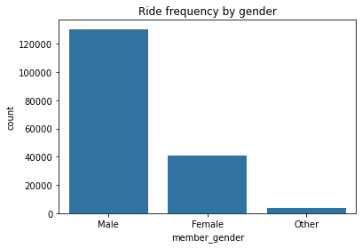

```python
freq = ford_2019['member_gender'].value_counts()
gender = freq.index

sb.countplot(data=ford_2019, x='member_gender', color=base_color, order = gender)

plt.title('Ride frequency by gender');
```

### What are the chances that a ride is shared among users?

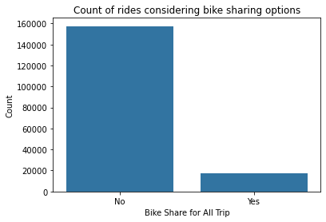

```python
sb.countplot(data=ford_2019, x='bike_share_for_all_trip', color=base_color)

plt.title('Count of rides considering bike sharing options')
plt.xlabel('Bike Share for All Trip')
plt.ylabel('Count');
```

Having bike shares of less than 20000 and otherwise at almost 160000, it is safe to say that the chances of riding alone are higher than riding with a partner

### What are most frequently used stations to start and end trips?

After plotting the initial distribution for start and end stations with all of the available station names in this dataset, the results were untidy as there was a lot of chart junk. I have resulted to using only the top 30 stations for the purpose of this project.

```python
start_counts = ford_2019['start_station_name'].value_counts().reset_index(name='number_of_trips')[:30]
start_order = start_counts['index']
```

```python
start_sub = ford_2019.loc[ford_2019['start_station_name'].isin(start_order)]
```

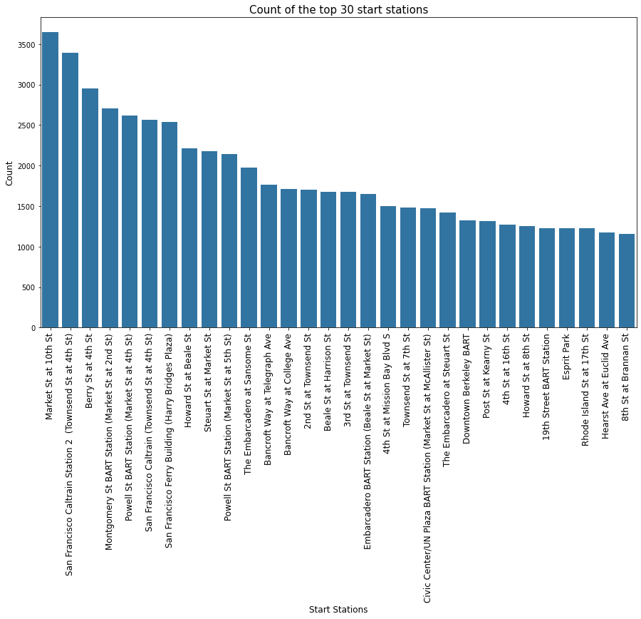

```python
plt.figure(figsize=[15,8])
ax=sb.countplot(data=start_sub,x='start_station_name', color=base_color, order=start_order)
plt.xticks(rotation=90, size = 12)
plt.xlabel('Start Stations', size = 12)
plt.ylabel('Count', size = 12)
plt.title('Count of the top 30 start stations', size = 15);
```

```python
end_counts = ford_2019['end_station_name'].value_counts().reset_index(name='number_of_trips')[:30]
end_order = end_counts['index']
```

```python
end_sub = ford_2019.loc[ford_2019['end_station_name'].isin(end_order)]
```

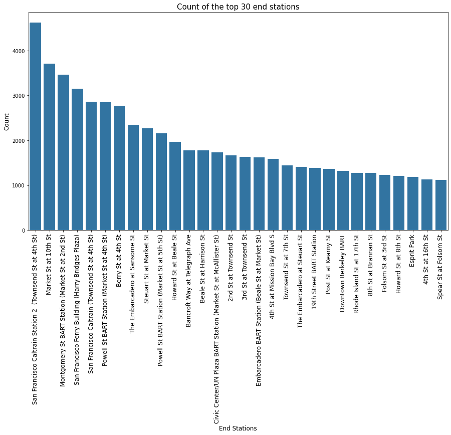

```python
plt.figure(figsize=[15,8])
ax=sb.countplot(data=end_sub,x='end_station_name', color=base_color, order=end_order)
plt.xticks(rotation=90, size = 12)
plt.xlabel('End Stations', size = 12)
plt.ylabel('Count', size = 12)
plt.title('Count of the top 30 end stations', size = 15);
```

> **Observation:** the most frequently visited stations are the Market St at 10th St and the San Francisco Caltrain Station 2(Townsend st at 4th st). This could be as a result of the number of customers or subscribers that are within their vicinity.

### Discuss the distribution(s) of your variable(s) of interest. Were there any unusual points? Did you need to perform any transformations?

#### Distance

> The distance distribution is a unimodal one which was realized only after plotting it to a log scale and reducing the bins. The initial plot did not give enough information as it only indicated that over 95% of the rides were less than 10km in distance. Although this is correct, the graph did not show the flow across different distances and the amount of times thosed distances were covered. After the bins were reduced and replotted on a log scale, I observed that the majority of the users did not travel far distances and stayed within the range of 0.7 to 3Kms with 1.5Km being the singular distance covered by the most users.

#### Gender

> The male gender accounts for most of the users of the bike services.

#### Duration

> Although there were some outliers where duration was longer than 300 minutes, the most frequent were between 3 to 30 minutes. This could either be because the rides are used only for shorter distances or the users conveniently travel short distances when using this bike service.

#### Time of day/Day

> The histograms above indicate that most rides were taken on weekdays, in the mornings and evenings while the least were recorded during the weekend, at night and twilight. Although Thursdays have the most rides recorded on February, ride records during the weekdays are significantly higher than during the weekend. We can attribute this to the fact that workdays are mostly during the weekdays and rush hours are usually in the mornings, when people leave for work, and in the evening, when they return.

#### Age

> After applying smaller bin sizes and logarithmic scaling it is clearly evident that the distribution is spread across different ages with most of the riders being less than 50 years old, particularly 25-40 years, and the youngest being less than 20 years old but older than 15.

### Of the features you investigated, were there any unusual distributions? Did you perform any operations on the data to tidy, adjust, or change the form of the data? If so, why did you do this?

> Initially there were some unusual distributions like with the age, distance and duration plots but after transforming to a log scale, the distributions were clearer and more evident.

> Before carrying out the visualizations, I made some changes to the original dataset, cleaned it up and dropped values that were not relevant to my analysis. I added several columns which I later used for the univariate visualizations and which will still be used for further analysis.

## Bivariate Exploration

### How does age affect other factors?

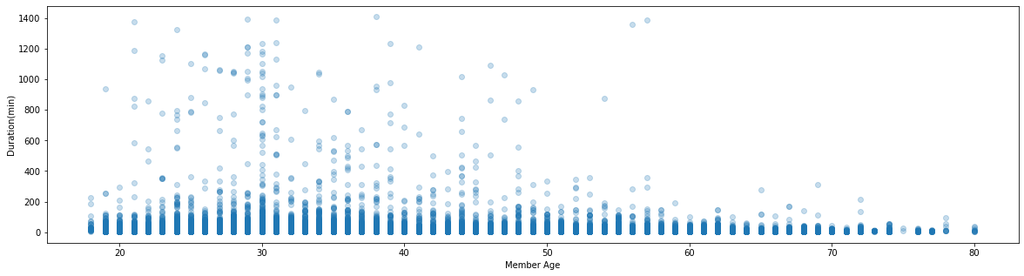

```python
plt.figure(figsize=[20,5])

plt.scatter(data = ford_2019, x = 'age', y = 'duration_min', alpha = 0.25);
plt.xlabel('Member Age')
plt.ylabel('Duration(min)');
```

**Observation**

> This does not show us much to work with as a lot of the actual durations, from our initial univariate exploration, are below 100 minutes. There are several visible outliers in this plot so to get a better view of this relationship, I'll filter out the outliers and replot.

```python
actual_time = ford_2019.query('duration_min <= 100')
```

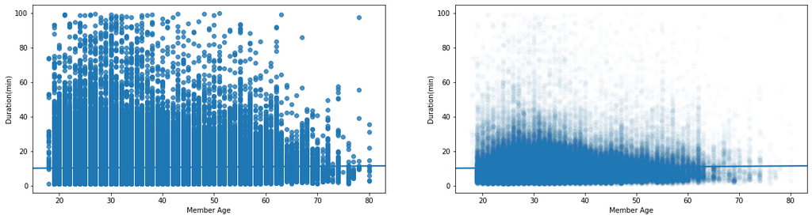

```python
plt.figure(figsize=[20,5])

#plot of age vs duration
plt.subplot(1,2,1)
sb.regplot(data = actual_time, x = 'age', y = 'duration_min', truncate=False);
plt.xlabel('Member Age')
plt.ylabel('Duration(min)');

#plot with jitter and transparency
plt.subplot(1,2,2)
sb.regplot(data = actual_time, x = 'age', y = 'duration_min', truncate=False,  x_jitter=0.2, scatter_kws={'alpha':1/50})
plt.xlabel('Member Age')
plt.ylabel('Duration(min)');
```

```python
def age_distance():
    sb.regplot(data = ford_2019, x = 'age', y = 'distance', truncate=False)

    plt.title('Distribution of distance covered by age of rider')
    plt.xlabel('Rider Age')
    plt.ylabel('Distance(Km)');
```

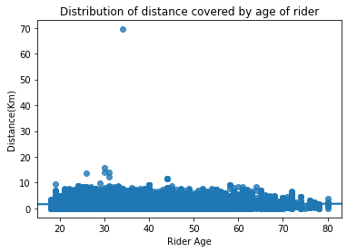

```python
age_distance()
```

> Filter out outliers and replot. Outliers from our initial plot on distance covered seem to reflect after 10Kms, Therefore to get the true view of this plot the maximum distance should be 10Km

```python
actual_dist = ford_2019.query('distance <= 10')
```

```python
def age_distance():
    plt.figure(figsize = [15, 8])
    plt.scatter(data = actual_dist, x = 'age', y = 'distance', alpha = 0.05);
    plt.title('Distribution of distance covered by age of rider')
    plt.xlabel('Rider Age')
    plt.ylabel('Distance(Km)');
```

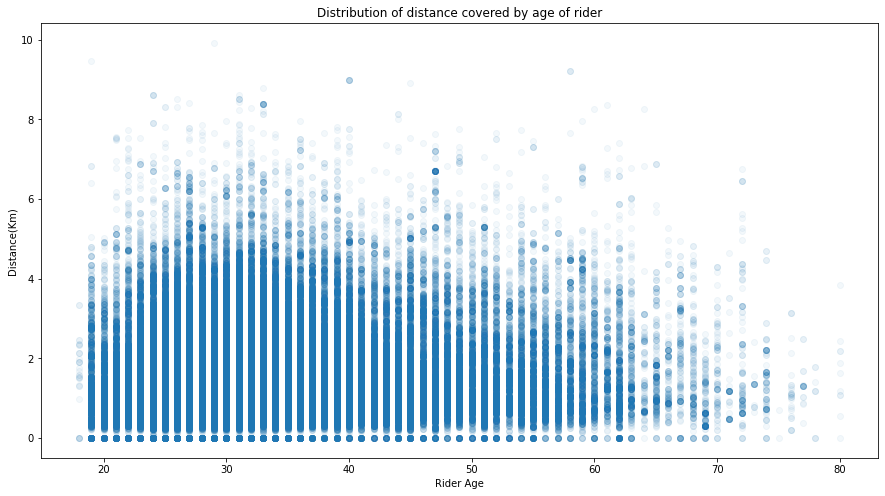

```python
age_distance()
```

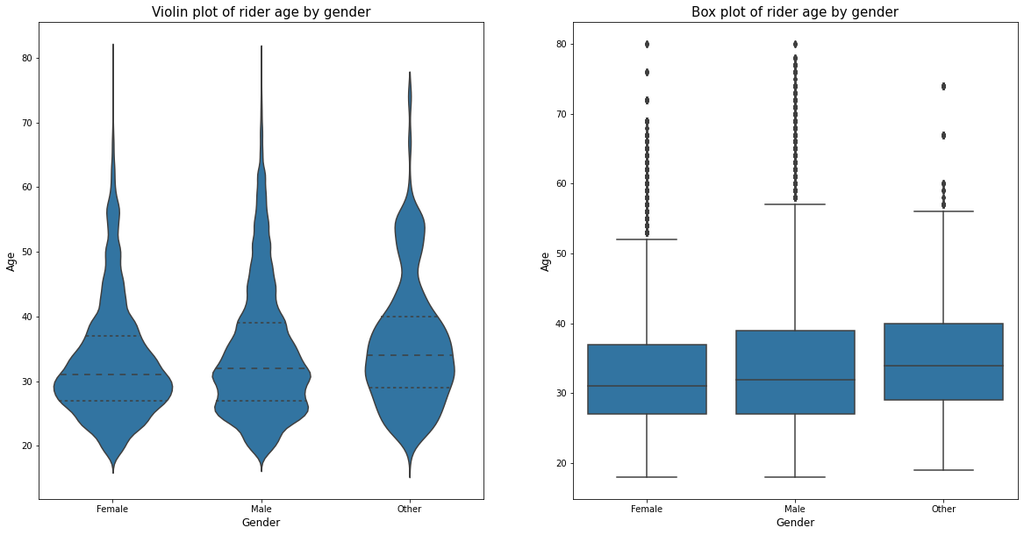

```python
plt.figure(figsize = [20,10])
plt.subplot(1,2,1)
sb.violinplot(data=ford_2019, x='member_gender', y='age', color = base_color, inner = 'quartile');
plt.title('Violin plot of rider age by gender', size = 15)
plt.xlabel('Gender',size = 12)
plt.ylabel('Age', size = 12);

plt.subplot(1,2,2)
sb.boxplot(data=ford_2019, x='member_gender', y='age', color = base_color);
plt.title('Box plot of rider age by gender', size = 15)
plt.xlabel('Gender', size = 12)
plt.ylabel('Age', size = 12);
```

**Observation**

> From the comparison between gender and age, there are much more younger people(ages of 20 to 45) than there are older people. which means that further investigation will produce results where there is more congestion around the younger ages than the older. The female gender seems to have the least median.

### What is the effect of gender on distance and duration?

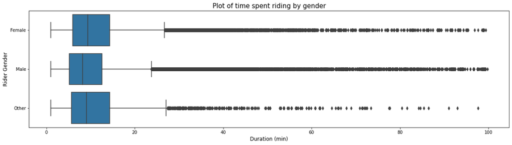

```python
plt.figure(figsize = [20, 5])

sb.boxplot(data = actual_time, x='duration_min', y='member_gender', color = base_color);

plt.title('Plot of time spent riding by gender', size = 15)
plt.ylabel('Rider Gender', size = 12)
plt.xlabel('Duration (min)', size = 12);
```

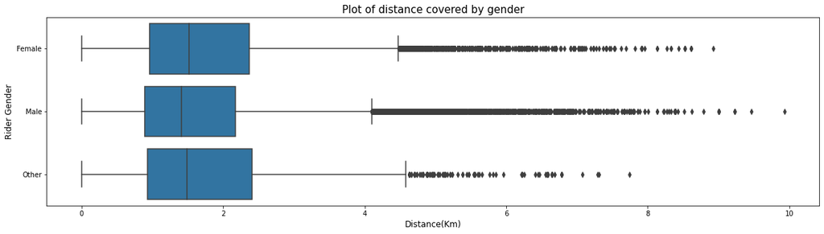

```python
plt.figure(figsize = [20, 5])
sb.boxplot(data=actual_dist, x='distance', y='member_gender', color = base_color)

plt.title('Plot of distance covered by gender', size = 15)
plt.ylabel('Rider Gender', size = 12)
plt.xlabel('Distance(Km)', size = 12);
```

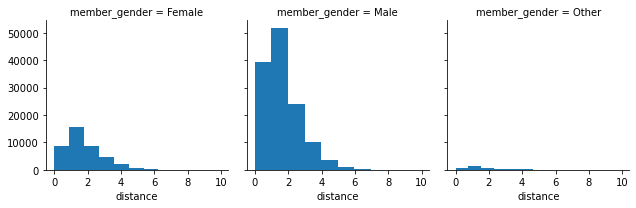

```python
# Plot the Seaborn's FacetGrid
g = sb.FacetGrid(data = actual_dist, col = 'member_gender')
g.map(plt.hist, "distance");
```

**Observation**

> Athough the boxplot comparing the distance and gender clearly depicts that the number of males is higher than that of the other genders, it doesnt clearly indicate by how much. It also does not show the regression or progression as we move along the distance axis.The facet grid however, shows all of that. It shows the differences in all the genders when plotted to the same scale. It also gives us a view of the rise and drop as distance increases. From this plot we can conclude that, irrespective of gender, as distance increases, the count of riders reduce. The only peak observed is between 1 - 2 Kms indicating that most riders travel short distances.

### Compare user types with both distance and duration

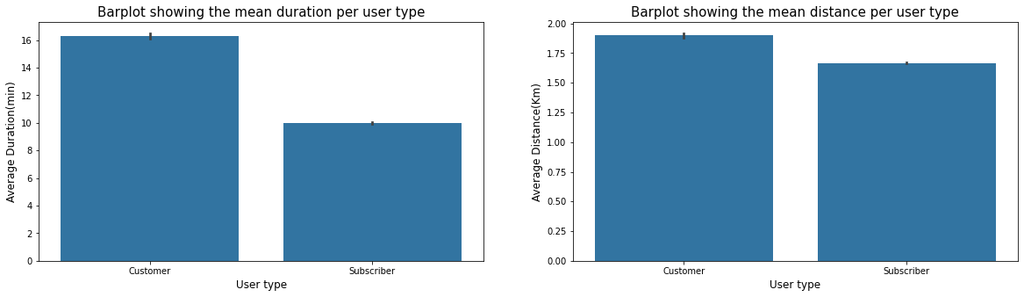

```python
plt.figure(figsize = [20,5])
plt.subplot(1,2,1)
sb.barplot(data = actual_time, x='user_type', y='duration_min', color = base_color)
plt.title('Barplot showing the mean duration per user type', size = 15)
plt.xlabel('User type',size = 12)
plt.ylabel('Average Duration(min)', size = 12);

plt.subplot(1,2,2)
sb.barplot(data = actual_dist, x='user_type', y='distance', color = base_color);
plt.title('Barplot showing the mean distance per user type', size = 15)
plt.xlabel('User type', size = 12)
plt.ylabel('Average Distance(Km)', size = 12);
```

#### Observation

> Although there are more subscribers who use the bike services than customers, customers rode further distances and spent more time riding than subscribers when considering the averages withour outliers.

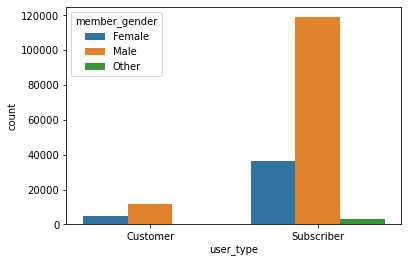

```python
sb.countplot(data = ford_2019, x= 'user_type', hue = 'member_gender');
```

### What is the frequency of riders per day at a given time?

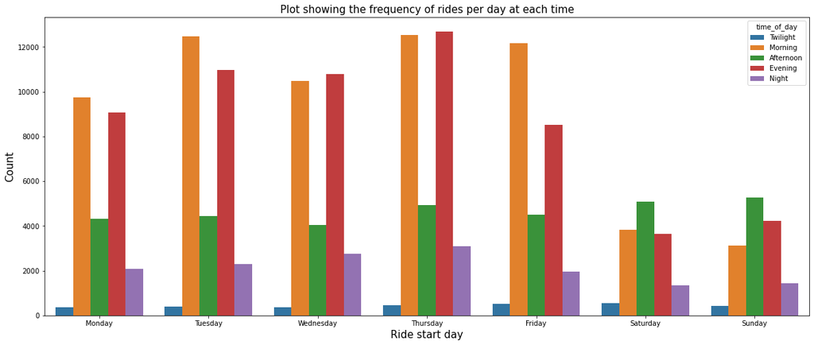

```python
plt.figure(figsize = [20,8])
sb.countplot(data = ford_2019, x= 'start_day', hue = 'time_of_day');

plt.title('Plot showing the frequency of rides per day at each time', size = 15)
plt.ylabel('Count', size = 15)
plt.xlabel('Ride start day', size = 15);
```

Generally, there is a trend of high rise in the mornings and evenings of the weekdays. While the rides at night and during the twilight period are low everyday, the frequency of rides during the weekends is relatively lower than all other days.

### Does distance affect the duration of a ride?

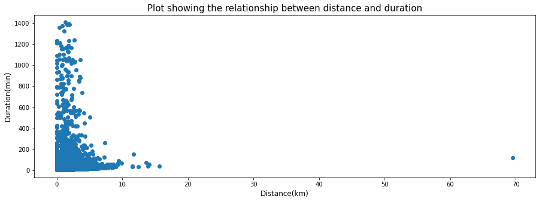

```python
plt.figure(figsize = [15,5])
plt.scatter(data = ford_2019, x = 'distance', y = 'duration_min')

plt.title('Plot showing the relationship between distance and duration', size = 15)
plt.ylabel('Duration(min)', size = 12)
plt.xlabel('Distance(km)', size = 12);
```

```python
#filter outliers from both distance and duration
dist_dur = ford_2019[(ford_2019.distance <= 10) & (ford_2019.duration_min <= 100)]
```

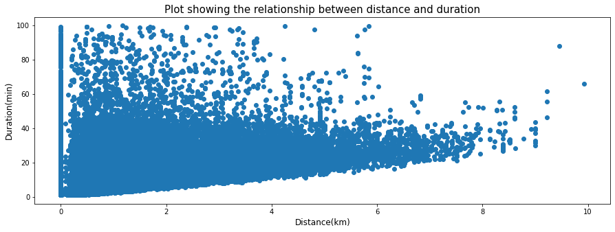

```python
plt.figure(figsize = [15,5])
plt.scatter(data = dist_dur, x = 'distance', y = 'duration_min')

plt.title('Plot showing the relationship between distance and duration', size = 15)
plt.ylabel('Duration(min)', size = 12)
plt.xlabel('Distance(km)', size = 12);
```

### Talk about some of the relationships you observed in this part of the investigation. How did the feature(s) of interest vary with other features in the dataset?

> There average distance covered by customers was more than that covered by subscribers irrespective of the fact that there are more subscribers than customers. Also, average duration spent per ride was higher for customers than for subscribers.

> Because there are generally more males than female or other genders, they tend to dominate the chart when compared to other features in this dataset. However, when compared with other genders and considering average distance covered and duration spent per ride, females and others were relatively higher than the male average.

### Did you observe any interesting relationships between the other features (not the main feature(s) of interest)?

> The relationship between distance and duration shows that, for the majority, there is an increase in duration as distance increases. However, there are some cases where some rides took longer than others even though they covered shorter distances. This could be attributed to the fact that some riders made numerous stops before getting to the end station. It could also mean that some riders just move really fast or slowly.

## Multivariate Exploration

### Bike shares relationship with distance and duration.

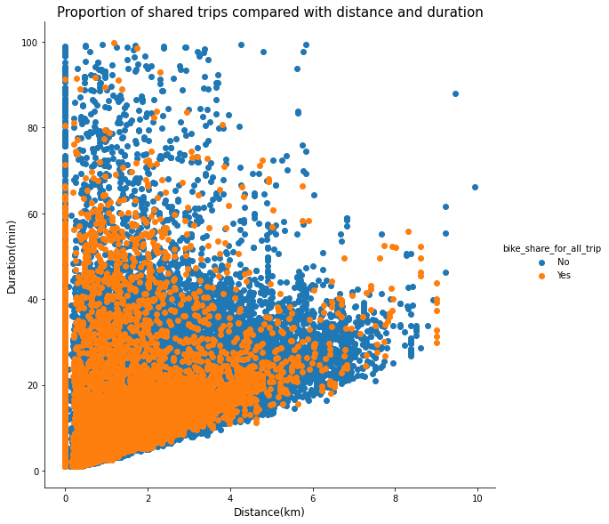

```python
g = sb.FacetGrid(data = dist_dur, hue = 'bike_share_for_all_trip', height = 8)
g.map(plt.scatter, 'distance', 'duration_min')
g.add_legend()

plt.title('Proportion of shared trips compared with distance and duration', size = 15)
plt.ylabel('Duration(min)', size = 12)
plt.xlabel('Distance(km)', size = 12);
```

**Observation**

Outside of the short distance short duration zone, rides are hardly shared.

### Age comparison with distance and duration.

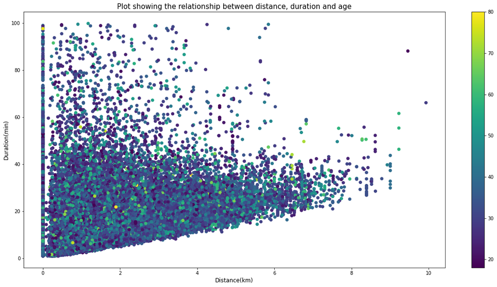

```python
plt.figure(figsize = [20,10])

plt.scatter(data = dist_dur, x = 'distance', y = 'duration_min', c = 'age')
plt.colorbar();

plt.title('Plot showing the relationship between distance, duration and age', size = 15)
plt.ylabel('Duration(min)', size = 12)
plt.xlabel('Distance(km)', size = 12);
```

The chart clearly shows a progression indicating the time increase with increasing distance. It also shows the age distribution across the chart with ages ranging from 18 to 50 being more frequent and ages >50 less frequent on the plot.

### User type/gender comparison with duration and day.

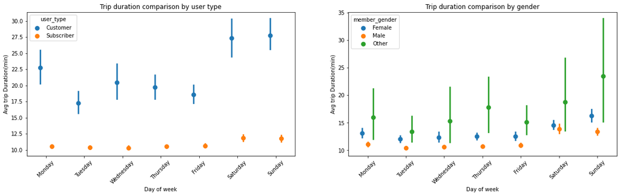

```python
plt.figure(figsize = [20,5])

plt.subplot(1,2,1)
sb.pointplot(data=ford_2019, x='start_day', y='duration_min', hue='user_type', dodge=0.3, linestyles="");

plt.xticks(rotation = 45)
plt.title('Trip duration comparison by user type')
plt.xlabel('Day of week')
plt.ylabel('Avg trip Duration(min)')

plt.subplot(1,2,2)
sb.pointplot(data=ford_2019, x='start_day', y='duration_min', hue='member_gender', dodge=0.3, linestyles="");

plt.xticks(rotation = 45)
plt.title('Trip duration comparison by gender')
plt.xlabel('Day of week')
plt.ylabel('Avg trip Duration(min)');
```

### Talk about some of the relationships you observed in this part of the investigation. Were there features that strengthened each other in terms of looking at your feature(s) of interest?

**Start day vs Duration vs User type**

> Multivariate exploration reinforces some of the patterns found in previous bivariate and univariate explorations, visualizing the relationships between multiple presented variables as a whole and presenting information in combination.

### Were there any interesting or surprising interactions between features?

> The short efficient usage time of subscribers corresponds to the high concentration during rush hours from Monday to Friday, indicating that usage is mainly for commuting. The more relaxed and flexible usage behavior of customers indicates that they use the bike-sharing system in a very different way than their subscribers, presumably for tourism and leisure purposes, and more on weekends and afternoons.

## Conclusions

> While the univariate exploration helped in uderstanding each feature better, the user_type distribution, the distance frequency, the time spent frequency as well as the bike sharing distribution, the multivariate and bivariate explorations gave a better understanding of the relationships between each feature, showcasing its high, low points as well as the outliers.